# evCalc Demo

James Del Mutolo

2025-04-14

## evCalc Package

The evCalc (Electric Vehicle Calculator) package contains functions for calculating metrics such as efficiency, estimated range, battery degradation, etc, from raw OBD2 data gathered from an electric vehicle.

## Loading the evCalc Package

The evCalc package can be installed directly from GitHub using the install_github() function from devtools.

```r
devtools::install_github("delmutoloj/evCalc")
```

## Datasets

The evCalc package contains the following datasets:

**In-city traffic** – Log for in-city driving, used for calculating efficiency (in progress)

**Full discharge** – Very lengthy log of as close to a full discharge as possible (preferably 100%-5%). Used to calculate degradation.

**DC fast charging session** – Log of power and temperature during a DC fast charging session. Used to create charging curve.

## Functions

**duration()**

Simply returns the duration of logging dataset in minutes.

```r
library(evCalc)

duration(log_degradation)
```

```
## [1] 160.7666
```

```r
duration(log_40mph)
```

```
## [1] 4.991683
```

**capacity()**

Estimate total battery capacity in kWh.

```r
capacity(log_degradation)
```

```
## [1] 62.16143
```

We calculate 62.16 kWh of usable energy.

**degradation()**

Compare estimated battery capacity to factory capacity (66 kWh) to calculate degradation in percent decrease.

```r
degradation(log_degradation, 66)
```

```
## [1] -5.816019
```

We calculate a 5.8% decrease in total battery capacity.

**estimatedRange()**

The estimatedRange() function calculates range in miles based on the efficiency and projected battery capaicty of a given log.

```r
estimatedRange(log_degradation)
```

```
## [1] 195.1097
```

```r
estimatedRange(log_90mph)
```

```
## [1] 126.7007
```

## Comparing Efficiency

Lets use the included datasets to compare vehicle efficiency at different speeds.

```r
library(ggplot2)

# Calculate efficiency at different speeds, store results in table
eff_table <- data.frame(
  Speed_mph = c(40, 50, 60, 70, 80, 90),
  Efficiency_mi_per_kWh = c(
    efficiency(log_40mph),
    efficiency(log_50mph),
    efficiency(log_60mph),
    efficiency(log_70mph),
    efficiency(log_80mph),
    efficiency(log_90mph)
  )
)

# Print efficiency table
print(eff_table)
```

```
##   Speed_mph Efficiency_mi_per_kWh
## 1        40              5.985972
## 2        50              4.501435
## 3        60              4.375991
## 4        70              3.498407
## 5        80              2.667952
## 6        90              2.098121
```

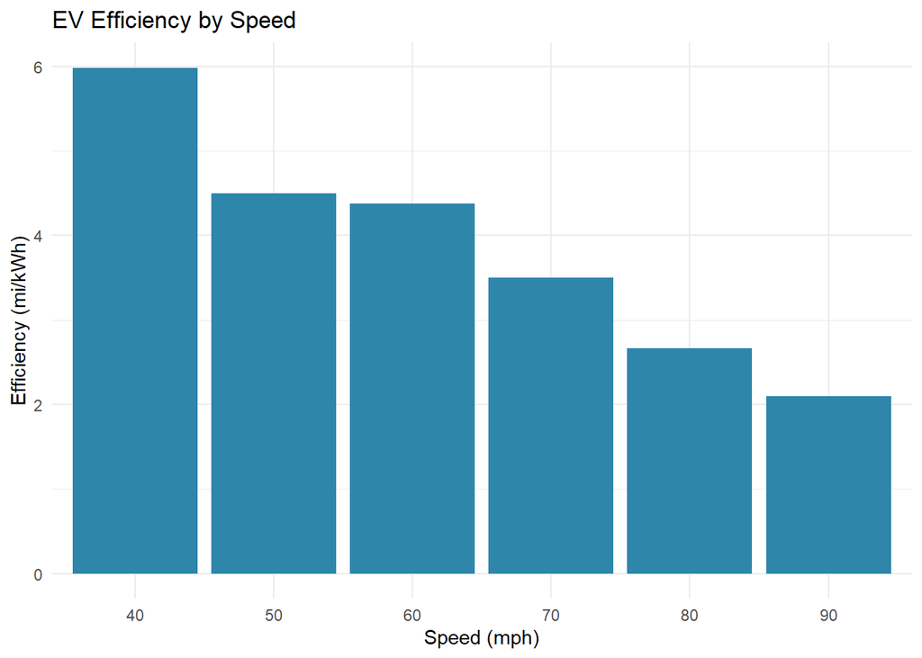

```r
# Barplot for efficiency by speed
ggplot(eff_table, aes(x = factor(Speed_mph), y = Efficiency_mi_per_kWh)) +
  geom_bar(stat = "identity", fill = "#2E86AB") +
  labs(
    title = "EV Efficiency by Speed",
    x = "Speed (mph)",
    y = "Efficiency (mi/kWh)"
  ) +
  theme_minimal()
```

```r
# Calculate range given 62 kWh estimated capacity, store results in table.
range_table <- data.frame(
  Speed_mph = c(40, 50, 60, 70, 80, 90),
  Range_mi = c(
    efficiency(log_40mph) * 62,
    efficiency(log_50mph) * 62,
    efficiency(log_60mph) * 62,
    efficiency(log_70mph) * 62,
    efficiency(log_80mph) * 62,
    efficiency(log_90mph) * 62
  )
)

# Print range table
print(range_table)
```

```
##   Speed_mph Range_mi
## 1        40 371.1302
## 2        50 279.0890
## 3        60 271.3115
## 4        70 216.9012
## 5        80 165.4130
## 6        90 130.0835
```

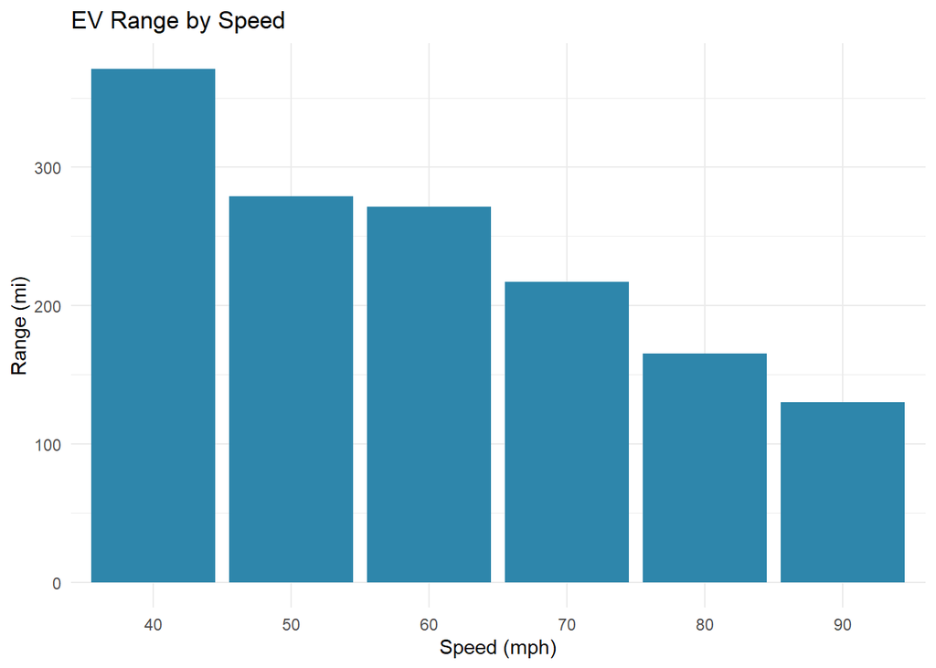

```r
# Barplot for range by speed
ggplot(range_table, aes(x = factor(Speed_mph), y = Range_mi)) +
  geom_bar(stat = "identity", fill = "#2E86AB") +
  labs(
    title = "EV Range by Speed",
    x = "Speed (mph)",
    y = "Range (mi)"
  ) +
  theme_minimal()
```